# Разработка дашборда с данными конференций TED

Заказчик — компания, которая приобрела лицензию на проведение конференций TED. Сейчас идёт этап организации первого мероприятия: заказчик ищет выступающих, подбирает темы и площадки. Компании важно провести мероприятие в духе классических конференций TED и сделать это так, чтобы оно было запоминающимся и интересным. Для этого заказчик хочет учитывать опыт проведённых конференций и просит разработать дашборд, который в этом поможет.

Нужно ответить на несколько вопросов:

- Какие темы популярны? Как зрители реагируют на них?
- Какое среднее количество выступающих на одной конференции?
- Какая средняя длина выступления? Как правильно организовать время проведения конференции?
- Кто из выступающих интересен зрителям?

## Что нужно сделать

Задача: разработать дашборд, позволяющий ответить на вопросы заказчика.

## Описание данных

Мы будем работать с данными о выступлениях на конференциях TED. В датасете три таблицы: `events`, `speakers` и `talks`.

Таблица `events`содержит информацию о конференциях:

- `conf_id` — идентификатор конференции. Первичный ключ таблицы;
- `event_name` — название конференции;
- `country` — страна проведения конференции.

Таблица `speakers` содержит информацию о выступающих:

- `author_id` — идентификатор выступающего (первичный ключ таблицы);
- `speaker_name` — имя выступающего;
- `speaker_occupation` — род деятельности выступающего;
- `speaker_description` — краткое описание выступающего.

Таблица `talks` содержит информацию о выступлениях:

- `talk_id` — идентификатор выступления (первичный ключ таблицы);
- `url` — интернет-ресурс, где выступление находится в открытом доступе;
- `title` — название выступления;
- `description` — краткое описание выступления;
- `film_date` — дата видеозаписи выступления;
- `duration` — длительность выступления;
- `views_count` — количество просмотров выступления;
- `main_tag` — основной тег выступления;
- `speaker_id` — идентификатор выступающего (внешний ключ, который связан со столбцом author_id таблицы speakers);
- `laughter_count` — число случаев, когда в зале звучал смех;
- `applause_count` — число случаев, когда в зале звучали аплодисменты;
- `language_sp` — язык, на котором велось выступление;
- `event_id` — идентификатор конференции (внешний ключ, который связан со столбцом conf_id таблицы events).

## Наполнение дашборда

### 1. Данные на верхнем уровне

Тут размещены показатели, которые помогут заказчику понять, на каком объёме данных строится дашборд и можно ли на них опираться:

- количество конференций (нужно учитывать все конференции, даже без выступлений);
- количество выступлений;
- уникальное количество выступающих;
- количество тем или тегов.

Чтобы с дашбордом было комфортно работать, добавлены селекторы по стране, названию конференции, тегу выступления и дате записи.

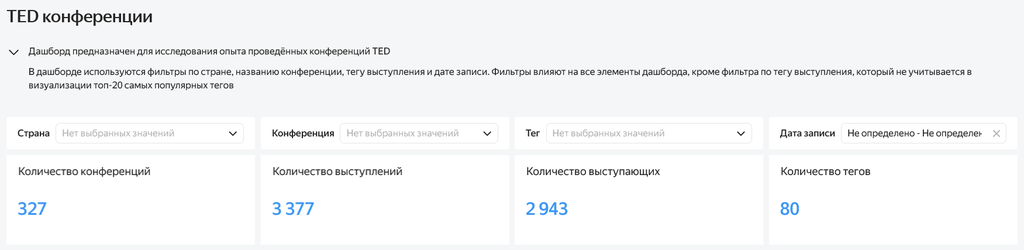

### 2. Подробная информация о конференциях

Реализована возможность сделать детализацию от страны к конференциям и увидеть такие показатели:

- средняя длительность выступления;
- максимальное количество просмотров, которое было у выступления;
- сколько раз аплодировали за всю конференцию;
- количество выступающих.

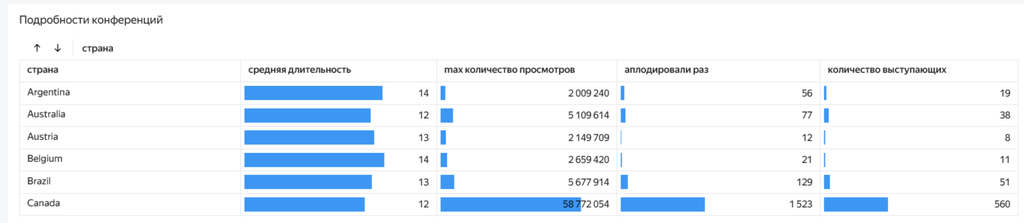

При выборе страны доступна информация о конференциях:

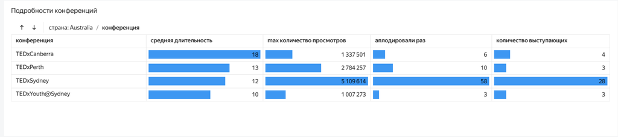

### 3. Исследование выступлений

Здесь размещена информация:

- топ-10 самых смешных выступлений,
- топ-20 самых популярных тегов.

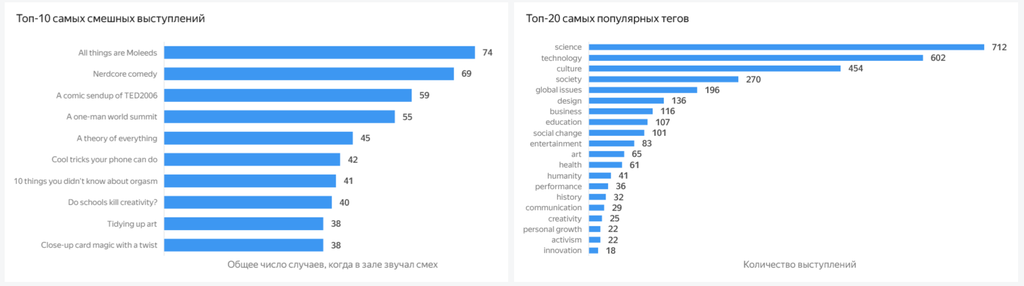

### 4. Информация о выступающих

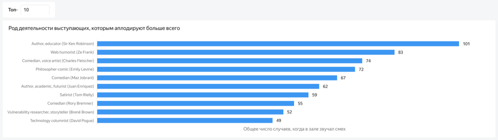

### 5. Подробности выступлений

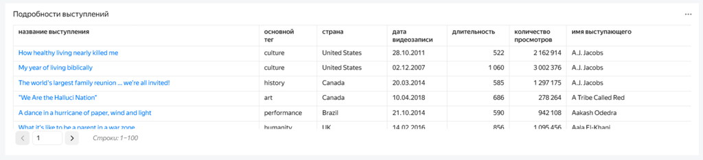

Общий вид дашборда:

[figure not shown]

С дашбордом можно ознакомиться по ссылке [ссылке](https://datalens.yandex/xf5a4serzdbwi)